# NYC_airport

1 Airline vs Delay

1.1 Data Exploration

1.1.1 Basic Information

1.1.2 Delay Type vs Airline

2 NYC airlines

2.0.1 General Infor

2.0.1.1 Airline Percentage

2.0.1.2 Get delay table for different airline

2.0.1.3 Airline percentage of airport delay (before normalization)

2.0.2 Airline Rank based on Delay Percentage

2.0.2.1 Hypothesis Testing for Delay Percentage Rank of All Airlines

2.0.2.2 Delay Percentage Ranking for All Airlines (Figure)

2.0.3 Airline vs Delay Type

2.0.3.1 Three Delay Type

2.0.3.2 Airline_Delay

2.0.3.3 Hypothesis Tesing for Airline_Delay

2.0.3.4 Airline_Delay vs flight time

2.0.3.5 Find the best and worst combinations at different time

2.0.3.6 delay percentage for each delay type for each airline

2.0.4 Airline vs Delay Time

2.0.4.1 Total delay time for different airports

2.0.4.2 Delay time for different airline (use EWR as an example)

2.0.4.3 Classify airline delay into different type based on delay time

# Airline vs Delay

```python
#style.use("ggplot")
!pip install statsmodels
!pip install pingouin
```

[output not shown]

```python
import numpy as np
import pandas as pd
import matplotlib.pyplot as plt
import seaborn as sns
import matplotlib
import matplotlib.patches as mpatches
import matplotlib.gridspec as gridspec
import matplotlib.style as style
import statsmodels.api as sm
from statsmodels.formula.api import ols
import statsmodels
from scipy import stats
from pingouin import pairwise_tests
%matplotlib inline
```

```python
import warnings
warnings.filterwarnings("ignore")
```

## Data Exploration

```python
flights = pd.read_csv("Final_11/flight_traffic.csv")
airlines = pd.read_csv("Final_11/airlines.csv")
airlines_stock = pd.read_csv("Final_11/stock_prices.csv")
```

```python
flights[['scheduled_departure', 'actual_departure', 'scheduled_arrival',
       'actual_arrival', 'cancelled', 'diverted', 'scheduled_elapsed',
       'actual_elapsed', 'distance', 'airline_delay', 'weather_delay',
       'air_system_delay', 'security_delay', 'aircraft_delay']].head(20)
```

|  | scheduled_departure | actual_departure | scheduled_arrival | actual_arrival | cancelled | diverted | scheduled_elapsed | actual_elapsed | distance | airline_delay | weather_delay | air_system_delay | security_delay | aircraft_delay |
| --- | --- | --- | --- | --- | --- | --- | --- | --- | --- | --- | --- | --- | --- | --- |
| 0 | 1619 | 1615.0 | 1856 | 1836.0 | 0 | 0 | 277.0 | 261.0 | 1773 | NaN | NaN | NaN | NaN | NaN |
| 1 | 1305 | 1256.0 | 1508 | 1505.0 | 0 | 0 | 123.0 | 129.0 | 632 | NaN | NaN | NaN | NaN | NaN |
| 2 | 1305 | 1314.0 | 1508 | 1502.0 | 0 | 0 | 123.0 | 108.0 | 632 | NaN | NaN | NaN | NaN | NaN |
| 3 | 1305 | 1304.0 | 1508 | 1513.0 | 0 | 0 | 123.0 | 129.0 | 632 | NaN | NaN | NaN | NaN | NaN |
| 4 | 1305 | 1301.0 | 1508 | 1457.0 | 0 | 0 | 123.0 | 116.0 | 632 | NaN | NaN | NaN | NaN | NaN |
| 5 | 1315 | 1306.0 | 1506 | 1443.0 | 0 | 0 | 111.0 | 97.0 | 600 | NaN | NaN | NaN | NaN | NaN |
| 6 | 925 | 920.0 | 1042 | 1023.0 | 0 | 0 | 77.0 | 63.0 | 226 | NaN | NaN | NaN | NaN | NaN |
| 7 | 625 | 624.0 | 818 | 807.0 | 0 | 0 | 113.0 | 103.0 | 590 | NaN | NaN | NaN | NaN | NaN |
| 8 | 1055 | 1050.0 | 1341 | 1417.0 | 0 | 0 | 286.0 | 327.0 | 1814 | 0.0 | 0.0 | 36.0 | 0.0 | 0.0 |
| 9 | 1055 | 1054.0 | 1341 | 1318.0 | 0 | 0 | 286.0 | 264.0 | 1814 | NaN | NaN | NaN | NaN | NaN |
| 10 | 2208 | 2203.0 | 2358 | 108.0 | 0 | 0 | 230.0 | 305.0 | 1464 | 0.0 | 0.0 | 70.0 | 0.0 | 0.0 |
| 11 | 2208 | 2204.0 | 2358 | 16.0 | 0 | 0 | 230.0 | 252.0 | 1464 | 0.0 | 0.0 | 18.0 | 0.0 | 0.0 |
| 12 | 2205 | 2206.0 | 2359 | 2346.0 | 0 | 0 | 234.0 | 220.0 | 1464 | NaN | NaN | NaN | NaN | NaN |
| 13 | 1955 | 1952.0 | 112 | 50.0 | 0 | 0 | 197.0 | 178.0 | 1488 | NaN | NaN | NaN | NaN | NaN |
| 14 | 1955 | 2130.0 | 112 | 231.0 | 0 | 0 | 197.0 | 181.0 | 1488 | 0.0 | 0.0 | 0.0 | 0.0 | 79.0 |
| 15 | 1240 | 1234.0 | 1521 | 1519.0 | 0 | 0 | 101.0 | 105.0 | 601 | NaN | NaN | NaN | NaN | NaN |
| 16 | 1820 | 1815.0 | 2338 | 2309.0 | 0 | 0 | 198.0 | 174.0 | 1330 | NaN | NaN | NaN | NaN | NaN |
| 17 | 1250 | 1244.0 | 1807 | 1731.0 | 0 | 0 | 197.0 | 167.0 | 1330 | NaN | NaN | NaN | NaN | NaN |
| 18 | 1840 | 1855.0 | 2358 | 2352.0 | 0 | 0 | 198.0 | 177.0 | 1330 | NaN | NaN | NaN | NaN | NaN |
| 19 | 1840 | 1835.0 | 2358 | 2345.0 | 0 | 0 | 198.0 | 190.0 | 1330 | NaN | NaN | NaN | NaN | NaN |

##### Note:

scheduled_elapsed = scheduled_arrival - scheduled_departure,  
actual_elapsed = actual_arrival - actual_departure,  
delay_time = actual_arrival(HHMM) - scheduled_arrival(HHMM)  
when canceled or diverted == 1, no information for delay  
taxi_off, taxi_in, wheels_off, wheels_in, are not accurate and have some problems, and we will not use these information

### Basic Information

```python
flights_use = flights.copy()
```

```python
airlines_names = airlines_names = {key: airlines[airlines["airline_id"] == key]["airline_name"].values[0] for key in set(flights_use["airline_id"])}
```

```python
flights_use.insert(1, "airline_name", list(map(lambda x:airlines_names[x].split()[0], list(flights_use["airline_id"]))))
```

```python
flights_use.columns
```

```
Index(['year', 'airline_name', 'month', 'day', 'airline_id', 'origin_airport',
       'destination_airport', 'scheduled_departure', 'actual_departure',
       'taxi_out', 'wheels_off', 'wheels_on', 'taxi_in', 'scheduled_arrival',
       'actual_arrival', 'cancelled', 'diverted', 'scheduled_elapsed',
       'actual_elapsed', 'distance', 'airline_delay', 'weather_delay',
       'air_system_delay', 'security_delay', 'aircraft_delay'],
      dtype='object')
```

```python
airlines_total = {df_tmp[0]:df_tmp[1].shape[0] for df_tmp in flights_use.groupby("airline_id")}
airlines_total_df = pd.DataFrame(index=airlines_total.keys(), data=airlines_total.values(), columns=["total_flights"])
```

```python
print(len(airlines_total), flights_use.shape[0])
```

```
12 567673
```

We have **12** airlines with **567673** flights information in 2017.  
The columns we have including 'year', 'month', 'day', 'airline_id', 'origin_airport','destination_airport', 'scheduled_departure', 'actual_departure','taxi_out', 'wheels_off', 'wheels_on', 'taxi_in', 'scheduled_arrival','actual_arrival', 'cancelled', 'diverted', 'scheduled_elapsed','actual_elapsed', 'distance', 'airline_delay', 'weather_delay','air_system_delay', 'security_delay', 'aircraft_delay'

### Delay Type vs Airline

```python
### get delay flight ###
flights_delay = flights_use[(flights_use["cancelled"] == 1)| (flights_use["diverted"] == 1) | (flights_use["airline_delay"].notnull())]
flights_delay["total_delay_time"] = flights_delay["airline_delay"] + flights_delay["weather_delay"] + flights_delay["air_system_delay"] + flights_delay["security_delay"] + flights_delay["aircraft_delay"]
#flights_delay.insert(1, "airline_name", list(map(lambda x:airlines_names[x].split()[0], list(flights_delay["airline_id"]))))
```

```python
flights_delay.shape
```

```
(112142, 27)
```

Based on delay information, we have **112142** flights delayed(including cancelled and diverted)

# NYC airlines

```python
### Three major airports in NYC
airport = pd.read_csv("Final_11/airports.csv", encoding = "ISO-8859-1")
airport[airport["airport_id"].isin(["LGA", "JFK", "EWR"])]
```

|  | airport_id | airport_name | city | state | latitude | longitude |
| --- | --- | --- | --- | --- | --- | --- |
| 106 | EWR | Newark Liberty International Airport | Newark | NJ | 40.69250 | -74.16866 |
| 166 | JFK | John F. Kennedy International AirportÎ¾(New Yo... | New York | NY | 40.63975 | -73.77893 |
| 182 | LGA | LaGuardia Airport (Marine Air Terminal) | New York | NY | 40.77724 | -73.87261 |

```python
### get schedule departure hour
hours = []
for time in list(flights_use["scheduled_departure"]):
    time = str(time)
    if int(time) >= 1000:
        if int(time[2:]) > 30:
            hours.append(int(time[0:2]) + 1)
        else:
            hours.append(int(time[0:2]))
    elif int(time) >= 100:
        if int(time[1:]) > 30:
            hours.append(int(time[0:1]) + 1)
        else:
            hours.append(int(time[0:1]))
    else:
        hours.append(24)
```

```python
flights_use["scheduled_departure_hour"] = hours
```

```python
NewYork_flights = flights_use[flights_use["origin_airport"].isin(["JFK", "LGA", "EWR"])]
NewYork_JFK_flights = flights_use[flights_use["origin_airport"] == "JFK"]
NewYork_LGA_flights = flights_use[flights_use["origin_airport"] == "LGA"]
NewYork_EWR_flights = flights_use[flights_use["origin_airport"] == "EWR"]
```

```python
hours = []
for time in list(flights_delay["scheduled_departure"]):
    time = str(time)
    if int(time) >= 1000:
        if int(time[2:]) > 30:
            hours.append(int(time[0:2]) + 1)
        else:
            hours.append(int(time[0:2]))
    elif int(time) >= 100:
        if int(time[1:]) > 30:
            hours.append(int(time[0:1]) + 1)
        else:
            hours.append(int(time[0:1]))
    else:
        hours.append(24)
```

```python
flights_delay["scheduled_departure_hour"] = hours
```

```python
NewYork_flights_delay = flights_delay[flights_delay["origin_airport"].isin(["JFK", "LGA", "EWR"])]
NewYork_JFK_flights_delay = flights_delay[flights_delay["origin_airport"] == "JFK"]
NewYork_LGA_flights_delay = flights_delay[flights_delay["origin_airport"] == "LGA"]
NewYork_EWR_flights_delay = flights_delay[flights_delay["origin_airport"] == "EWR"]
```

```python
### include cancelled and diverted
print("delay percentage in EWR", NewYork_EWR_flights_delay.shape[0]/NewYork_EWR_flights.shape[0])
```

```
delay percentage in EWR 0.2750149279194745
```

```python
print("delay percentage in JFK",NewYork_JFK_flights_delay.shape[0]/NewYork_JFK_flights.shape[0])
```

```
delay percentage in JFK 0.2597830710336027
```

```python
print("delay percentage in LGA",NewYork_LGA_flights_delay.shape[0]/NewYork_LGA_flights.shape[0])
```

```
delay percentage in LGA 0.2442658092175777
```

### General Infor

```python
print("There are ", len(set(NewYork_JFK_flights["airline_name"])), "airlines in JFK")
print("There are ", len(set(NewYork_EWR_flights["airline_name"])), "airlines in EWR")
print("There are ", len(set(NewYork_LGA_flights["airline_name"])), "airlines in LGA")
```

```
There are  6 airlines in JFK
There are  10 airlines in EWR
There are  10 airlines in LGA
```

```python
airline_names_list = ['Alaska', 'American', 'Delta', 'Hawaiian', 'Jetblue', 'Virgin',
                     'ExpressJet', 'SkyWest', 'Southwest', 'Spirit', 'United', 'Frontier']
```

#### Airline Percentage

```
JFK airline percentage
```

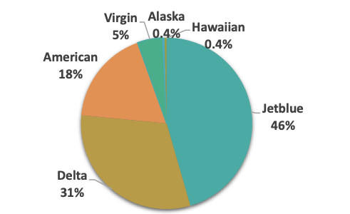

```python
### draw the pie figures using excel
from IPython.display import Image
print("JFK airline percentage")
Image("figures/pie1.png")
```

```
EWR airline percentage
```

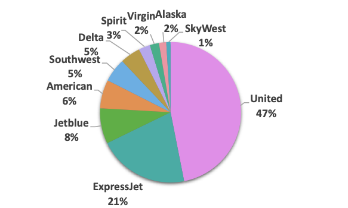

```python
print("EWR airline percentage")
Image("figures/pie2.png")
```

```
LGA airline percentage
```

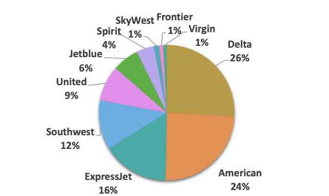

```python
print("LGA airline percentage")
Image("figures/pie3.png")
```

#### Get delay table for different airline

```python
def get_flight_problem(flights_delay, flights):
    '''
    return the delay type infor dic, with key as airlines id, value is the list for the number of each delay type
    '''
    problem_type = ['cancelled', 'diverted','airline_delay', 'weather_delay','air_system_delay', 'security_delay', 'aircraft_delay',]
    airlines = set(flights_delay["airline_name"])
    airlines_infor = {key:[] for key in airlines}
    for df_tmp in flights_delay.groupby("airline_name"):
        num_problems = [ df_tmp[1][(df_tmp[1][p] != 0.0) & (df_tmp[1][p].notnull())].shape[0] for p in problem_type]
        airlines_infor[df_tmp[0]] = num_problems
        airlines_infor[df_tmp[0]].append(df_tmp[1].shape[0])
        num_only_delay = df_tmp[1][df_tmp[1]["airline_delay"].notnull()].shape[0]
        airlines_infor[df_tmp[0]].append(num_only_delay)
        airlines_infor[df_tmp[0]].append(sum(df_tmp[1][df_tmp[1]["airline_delay"].notnull()]["total_delay_time"]))
        airlines_infor[df_tmp[0]].append(flights[flights["airline_name"]==df_tmp[0]].shape[0])
    return airlines_infor
```

```python
airline_EWR = get_flight_problem(NewYork_EWR_flights_delay, NewYork_EWR_flights)
airline_JFK = get_flight_problem(NewYork_JFK_flights_delay, NewYork_JFK_flights)
airline_LGA = get_flight_problem(NewYork_LGA_flights_delay, NewYork_LGA_flights)
```

```python
#### update airline infor
airline_EWR.update({key:[] for key in airline_names_list if key not in airline_EWR})
airline_JFK.update({key:[] for key in airline_names_list if key not in airline_JFK})
airline_LGA.update({key:[] for key in airline_names_list if key not in airline_LGA})
```

```python
airline_EWR_df = pd.DataFrame(index=airline_EWR.keys(), data=airline_EWR.values(), columns= ['cancelled', 'diverted','airline_delay', 'weather_delay','air_system_delay', 'security_delay', 'aircraft_delay', 'total_delay', 'only_delay', 'total_delay_time', "total_flights"])
airline_EWR_df.reset_index(inplace=True)
airline_JFK_df = pd.DataFrame(index=airline_JFK.keys(), data=airline_JFK.values(), columns= ['cancelled', 'diverted','airline_delay', 'weather_delay','air_system_delay', 'security_delay', 'aircraft_delay', 'total_delay', 'only_delay', 'total_delay_time', "total_flights"])
airline_JFK_df.reset_index(inplace=True)
airline_LGA_df = pd.DataFrame(index=airline_LGA.keys(), data=airline_LGA.values(), columns= ['cancelled', 'diverted','airline_delay', 'weather_delay','air_system_delay', 'security_delay', 'aircraft_delay', 'total_delay', 'only_delay', 'total_delay_time', "total_flights"])
airline_LGA_df.reset_index(inplace=True)
```

#### Airline percentage of airport delay (before normalization)

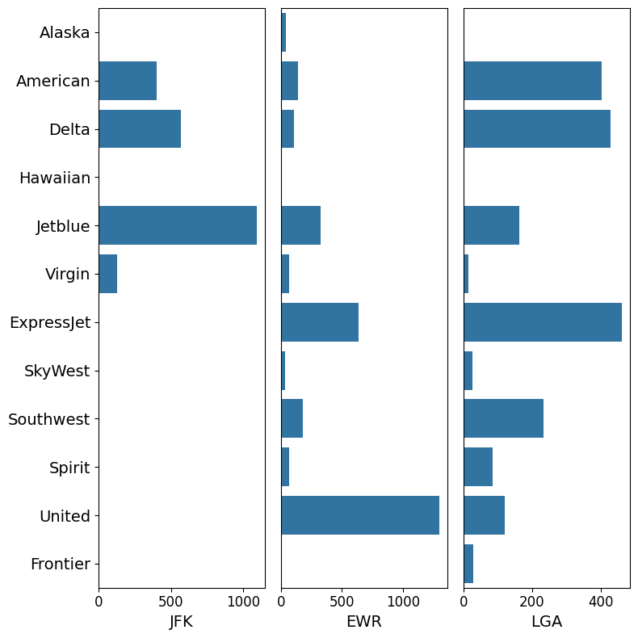

```python
plt.figure(figsize=(8, 8))

plt.subplot(131)
sns.barplot(x=[airline_JFK_df[airline_JFK_df["index"] == a]["only_delay"].values[0] for a in airline_names_list], y=list(airline_names_list),  orient="h")
plt.yticks(size=14)
plt.xticks(size=12)
plt.xlabel("JFK", size=14)

plt.subplot(132)
sns.barplot(x=[airline_EWR_df[airline_EWR_df["index"] == a]["only_delay"].values[0] for a in airline_names_list], y=list(airline_names_list), orient="h")
plt.yticks([], [])
plt.xticks(size=12)
plt.xlabel("EWR", size=14)

plt.subplot(133)
sns.barplot(x=[airline_LGA_df[airline_LGA_df["index"] == a]["only_delay"].values[0] for a in airline_names_list], y=list(airline_names_list), orient="h")
plt.yticks([], [])
plt.xticks(size=12)
plt.xlabel("LGA", size=14);

plt.tight_layout()
plt.show()
```

In JFK, Jetblue has the largest number of delay flights, for EWR, the largest one is United, and for LGA, the largest one is ExpressJet.  
However, in LGA, American, Delta and ExpressJet all have largest number of delay flights.

### Airline Rank based on Delay Percentage

```python
airline_EWR_df["delay_percentage"] = airline_EWR_df["only_delay"] / airline_EWR_df["total_flights"]
airline_JFK_df["delay_percentage"] = airline_JFK_df["only_delay"] / airline_JFK_df["total_flights"]
airline_LGA_df["delay_percentage"] = airline_LGA_df["only_delay"] / airline_LGA_df["total_flights"]
```

#### Hypothesis Testing for Delay Percentage Rank of All Airlines

```python
NewYork_EWR_flights["delay"] = np.where(NewYork_EWR_flights["airline_delay"].notnull(), 1, 0)
```

```python
NewYork_LGA_flights["delay"] = np.where(NewYork_LGA_flights["airline_delay"].notnull(), 1, 0)
```

```python
NewYork_JFK_flights["delay"] = np.where(NewYork_JFK_flights["airline_delay"].notnull(), 1, 0)
```

```python
pairwise_results_EWR = pairwise_tests(dv='delay', between = ['airline_name'], padjust='bonf', data=NewYork_EWR_flights)
pairwise_results_LGA = pairwise_tests(dv='delay', between = ['airline_name'], padjust='bonf', data=NewYork_LGA_flights)
pairwise_results_JFK = pairwise_tests(dv='delay', between = ['airline_name'], padjust='bonf', data=NewYork_JFK_flights)
```

```python
pairwise_results_EWR.head(9)
```

|  | Contrast | A | B | Paired | Parametric | T | dof | alternative | p-unc | p-corr | p-adjust | BF10 | hedges |
| --- | --- | --- | --- | --- | --- | --- | --- | --- | --- | --- | --- | --- | --- |
| 0 | airline_name | Alaska | American | False | True | 0.748859 | 288.876029 | two-sided | 0.454552 | 1.000000 | bonf | 0.117 | 0.061815 |
| 1 | airline_name | Alaska | Delta | False | True | 0.220228 | 337.369264 | two-sided | 0.825827 | 1.000000 | bonf | 0.095 | 0.018496 |
| 2 | airline_name | Alaska | ExpressJet | False | True | -2.003698 | 232.674105 | two-sided | 0.046262 | 1.000000 | bonf | 0.593 | -0.138044 |
| 3 | airline_name | Alaska | Jetblue | False | True | -4.278126 | 315.089560 | two-sided | 0.000025 | 0.001126 | bonf | 637.437 | -0.301097 |
| 4 | airline_name | Alaska | SkyWest | False | True | -1.698970 | 216.033508 | two-sided | 0.090764 | 1.000000 | bonf | 0.51 | -0.205780 |
| 5 | airline_name | Alaska | Southwest | False | True | -2.413847 | 354.869912 | two-sided | 0.016291 | 0.733086 | bonf | 1.552 | -0.185389 |
| 6 | airline_name | Alaska | Spirit | False | True | -0.644197 | 425.186342 | two-sided | 0.519795 | 1.000000 | bonf | 0.124 | -0.058331 |
| 7 | airline_name | Alaska | United | False | True | -1.243209 | 209.742254 | two-sided | 0.215179 | 1.000000 | bonf | 0.174 | -0.085829 |
| 8 | airline_name | Alaska | Virgin | False | True | -1.861897 | 432.965749 | two-sided | 0.063295 | 1.000000 | bonf | 0.566 | -0.175776 |

```python
pairwise_results_LGA[(pairwise_results_LGA["A"] == "United")|(pairwise_results_LGA["B"] == "United")]
```

|  | Contrast | A | B | Paired | Parametric | T | dof | alternative | p-unc | p-corr | p-adjust | BF10 | hedges |
| --- | --- | --- | --- | --- | --- | --- | --- | --- | --- | --- | --- | --- | --- |
| 7 | airline_name | American | United | False | True | 1.625567 | 1449.150879 | two-sided | 1.042592e-01 | 1.000000e+00 | bonf | 0.172 | 0.065184 |
| 15 | airline_name | Delta | United | False | True | 1.739696 | 1420.356006 | two-sided | 8.212896e-02 | 1.000000e+00 | bonf | 0.207 | 0.069062 |
| 22 | airline_name | ExpressJet | United | False | True | 9.086142 | 1979.237028 | two-sided | 2.420162e-19 | 1.089073e-17 | bonf | 1.558e+16 | 0.370693 |
| 28 | airline_name | Frontier | United | False | True | 2.742558 | 108.644916 | two-sided | 7.131778e-03 | 3.209300e-01 | bonf | 4.384 | 0.356977 |
| 33 | airline_name | Jetblue | United | False | True | 5.578448 | 1096.269481 | two-sided | 3.056004e-08 | 1.375202e-06 | bonf | 2.519e+05 | 0.313518 |
| 37 | airline_name | SkyWest | United | False | True | 1.503641 | 145.021113 | two-sided | 1.348483e-01 | 1.000000e+00 | bonf | 0.325 | 0.163630 |
| 40 | airline_name | Southwest | United | False | True | 3.326381 | 1812.140565 | two-sided | 8.973980e-04 | 4.038291e-02 | bonf | 12.482 | 0.151864 |
| 42 | airline_name | Spirit | United | False | True | 2.615189 | 685.487942 | two-sided | 9.113944e-03 | 4.101275e-01 | bonf | 2.004 | 0.169582 |
| 44 | airline_name | United | Virgin | False | True | -0.694120 | 87.665885 | two-sided | 4.894423e-01 | 1.000000e+00 | bonf | 0.166 | -0.089193 |

```python
pairwise_results_JFK[(pairwise_results_JFK["A"] == "Delta")|(pairwise_results_JFK["B"] == "Delta")]
```

|  | Contrast | A | B | Paired | Parametric | T | dof | alternative | p-unc | p-corr | p-adjust | BF10 | hedges |
| --- | --- | --- | --- | --- | --- | --- | --- | --- | --- | --- | --- | --- | --- |
| 1 | airline_name | Alaska | Delta | False | True | -0.261558 | 39.067292 | two-sided | 7.950366e-01 | 1.000000e+00 | bonf | 0.179 | -0.041306 |
| 5 | airline_name | American | Delta | False | True | 3.394317 | 3324.454658 | two-sided | 6.960593e-04 | 1.044089e-02 | bonf | 10.645 | 0.105768 |
| 9 | airline_name | Delta | Hawaiian | False | True | -0.451563 | 34.712406 | two-sided | 6.543927e-01 | 1.000000e+00 | bonf | 0.2 | -0.082256 |
| 10 | airline_name | Delta | Jetblue | False | True | -6.011600 | 6626.263912 | two-sided | 1.934644e-09 | 2.901966e-08 | bonf | 1.753e+06 | -0.141789 |
| 11 | airline_name | Delta | Virgin | False | True | -4.333697 | 549.767380 | two-sided | 1.743733e-05 | 2.615600e-04 | bonf | 610.863 | -0.244596 |

#### Delay Percentage Ranking for All Airlines (Figure)

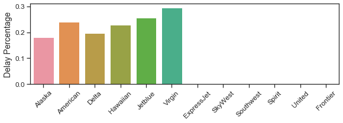

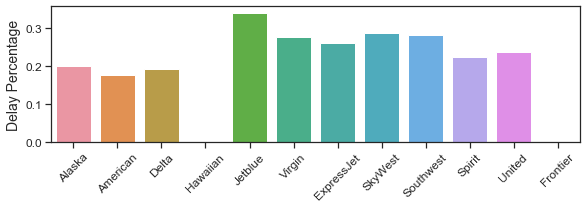

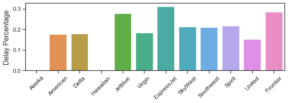

```python
#plt.subplots(figsize=[8,3],)
#plt.subplot(311)
plt.figure(figsize=[8,3])
sns.barplot(y=[airline_JFK_df[airline_JFK_df["index"] == a]["delay_percentage"].values[0] for a in airline_names_list], x=list(airline_names_list))
plt.yticks(size=12)
plt.xticks(size=12, rotation="45")
plt.tight_layout()
plt.ylabel("Delay Percentage", size=14)
plt.savefig("figures/rank_performance_JFK.pdf", dpi=300);
#plt.xlabel("JFK", size=14)
#plt.subplot(312)
plt.figure(figsize=[8,3])
sns.barplot(y=[airline_EWR_df[airline_EWR_df["index"] == a]["delay_percentage"].values[0] for a in airline_names_list], x=list(airline_names_list))
plt.yticks(size=12)
plt.xticks(size=12, rotation="45")
plt.tight_layout()
plt.ylabel("Delay Percentage", size=14)
plt.savefig("figures/rank_performance_EWR.pdf", dpi=300);
#plt.xlabel("EWR", size=14)
#plt.subplot(313)
plt.figure(figsize=[8,3])
sns.barplot(y=[airline_LGA_df[airline_LGA_df["index"] == a]["delay_percentage"].values[0] for a in airline_names_list], x=list(airline_names_list))
plt.yticks(size=12)
plt.xticks(size=12, rotation="45")
plt.tight_layout()
plt.ylabel("Delay Percentage", size=14);
#plt.xlabel("LGA", size=14)
plt.savefig("figures/rank_performance_LGA.pdf", dpi=300);
```

### Airline vs Delay Type

**Air Carrier**: The cause of the cancellation or delay was due to circumstances within the airline’s control (e.g. maintenance or crew problems, aircraft cleaning, baggage loading, fueling, etc.).  
**Extreme Weather**: Significant meteorological conditions (actual or forecasted) that, in the judgment of the carrier, delays or prevents the operation of a flight such as tornado, blizzard or hurricane.  
**National Aviation System (NAS)**: Delays and cancellations attributable to the national aviation system that refer to a broad set of conditions, such as non-extreme weather conditions, airport operations, heavy traffic volume, and air traffic control.  
**Late-arriving aircraft**: A previous flight with same aircraft arrived late, causing the present flight to depart late.  
**Security**: Delays or cancellations caused by evacuation of a terminal or concourse, re-boarding of aircraft because of security breach, inoperative screening equipment and/or long lines in excess of 29 minutes at screening areas.

#### Three Delay Type

```python
airdelay_type = {"airline_related":["airline_delay"],
                 "weather_related":["weather_delay"],
                 "airsystem_related": ["air_system_delay"]
                }
```

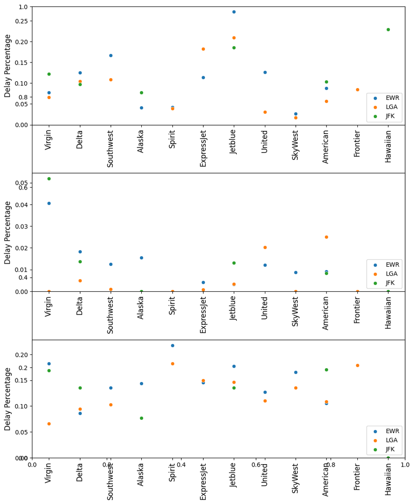

```python
airline_name_1 = [i for i in set(NewYork_EWR_flights["airline_name"])]
airline_name_2 = [i for i in set(NewYork_LGA_flights["airline_name"])]
airline_name_3 = [i for i in set(NewYork_JFK_flights["airline_name"])]
fig, ax = plt.subplots(figsize=[10,12])

for idx, (key, value) in enumerate(airdelay_type.items()):
    plt.subplot(3,1,idx+1)
    #plt.title(key.split("_")[0] + " delay", size=14)
    sns.scatterplot(x=airline_name_1,
                 y=[NewYork_EWR_flights_delay[(NewYork_EWR_flights_delay["airline_name"] == i) & (sum([NewYork_EWR_flights_delay[v] for v in value])!= 0.0) & (NewYork_EWR_flights_delay[value[0]].notnull())].shape[0]
                    / NewYork_EWR_flights[(NewYork_EWR_flights["airline_name"] == i)].shape[0] for i in airline_name_1], label="EWR")
    sns.scatterplot(x=airline_name_2,
                 y=[NewYork_LGA_flights_delay[(NewYork_LGA_flights_delay["airline_name"] == i) & (sum([NewYork_LGA_flights_delay[v] for v in value])!= 0.0) & (NewYork_LGA_flights_delay[value[0]].notnull())].shape[0]
                    / NewYork_LGA_flights[(NewYork_LGA_flights["airline_name"] == i)].shape[0] for i in airline_name_2], label="LGA")

    sns.scatterplot(x=airline_name_3,
                 y=[NewYork_JFK_flights_delay[(NewYork_JFK_flights_delay["airline_name"] == i) & (sum([NewYork_JFK_flights_delay[v] for v in value])!= 0.0) & (NewYork_JFK_flights_delay[value[0]].notnull())].shape[0]
                    / NewYork_JFK_flights[(NewYork_JFK_flights["airline_name"] == i)].shape[0] for i in airline_name_3], label="JFK")

    plt.ylim(ymin=0)
    plt.xticks(size=12)
    plt.ylabel("Delay Percentage", size=12)
    plt.xticks(rotation= 90, size=12)
    plt.legend(loc="lower right")

plt.tight_layout();
plt.show()
```

#### Airline_Delay

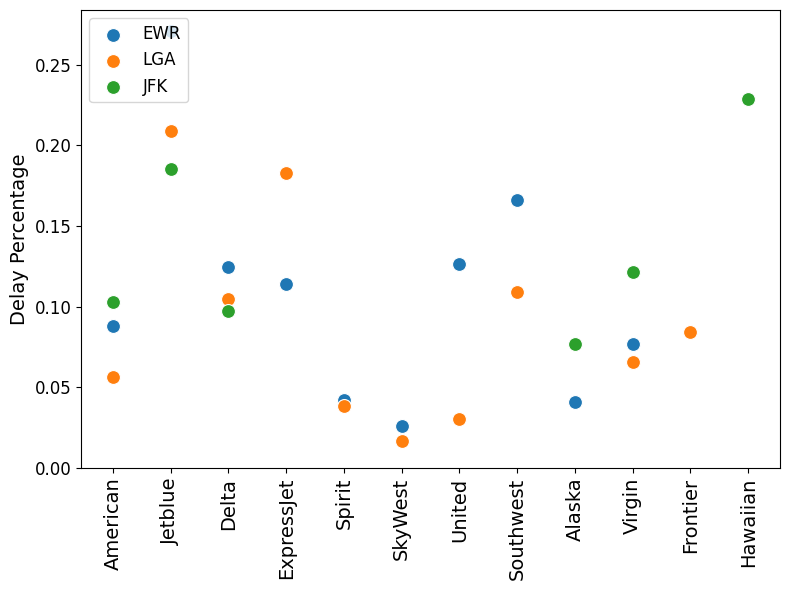

```python
# Airline name lists (preserve order with unique)
airline_name_1 = NewYork_EWR_flights["airline_name"].unique()
airline_name_2 = NewYork_LGA_flights["airline_name"].unique()
airline_name_3 = NewYork_JFK_flights["airline_name"].unique()

# Airport data mapping
airport_data = {
    "EWR": (airline_name_1, NewYork_EWR_flights, NewYork_EWR_flights_delay),
    "LGA": (airline_name_2, NewYork_LGA_flights, NewYork_LGA_flights_delay),
    "JFK": (airline_name_3, NewYork_JFK_flights, NewYork_JFK_flights_delay)
}

delay_col = "airline_delay"  # column to check

# Create figure
fig, ax = plt.subplots(figsize=(8, 6))

# Loop through airports and plot
for airport, (airline_names, df_all, df_delay) in airport_data.items():
    y_values = [
        df_delay[
            (df_delay["airline_name"] == name) &
            (df_delay[delay_col] != 0.0) &
            (df_delay[delay_col].notnull())
        ].shape[0] / df_all[df_all["airline_name"] == name].shape[0]
        for name in airline_names
    ]

    sns.scatterplot(x=airline_names, y=y_values, label=airport, s=100, ax=ax)

# Formatting
ax.set_ylim(bottom=0)
ax.set_ylabel("Delay Percentage", size=14)
ax.tick_params(axis="x", labelsize=14, rotation=90)
ax.tick_params(axis="y", labelsize=12)
ax.legend(loc="upper left", fontsize=12)

plt.tight_layout()
#plt.savefig("figures/Airline_caused_delay.pdf", dpi=300)
plt.show()
```

**SkyWest**'s performance is always **good**, and Skywest in LGA achieves the best performance;  
**Jetblue**'s performance is always **bad**, and Jetblue in EWR achieves the worst performance

#### Hypothesis Tesing for Airline_Delay

```python
NewYork_flights["airline_delay_number"] = np.where(NewYork_flights["airline_delay"].notnull() & NewYork_flights["airline_delay"] != 0.0, 1, 0)
```

```python
Best_Worst = NewYork_flights[((NewYork_flights["airline_name"] == "Jetblue") & (NewYork_flights["origin_airport"] == "EWR"))
                            |((NewYork_flights["airline_name"] == "SkyWest") & (NewYork_flights["origin_airport"] == "LGA"))]
```

```python
pairwise_results_airline = pairwise_tests(dv='airline_delay_number', between = 'airline_name', padjust='bonf', data=Best_Worst)
```

```python
pairwise_results_airline
```

|  | Contrast | A | B | Paired | Parametric | T | dof | alternative | p-unc | BF10 | hedges |
| --- | --- | --- | --- | --- | --- | --- | --- | --- | --- | --- | --- |
| 0 | airline_name | Jetblue | SkyWest | False | True | 13.598429 | 559.767376 | two-sided | 1.355807e-36 | 2.928e+35 | 0.602084 |

#### Airline_Delay vs flight time

```python
print(NewYork_EWR_flights_delay.columns)
```

[output not shown]

```python
print(NewYork_EWR_flights.columns)
```

```
Index(['year', 'airline_name', 'month', 'day', 'airline_id', 'origin_airport',
       'destination_airport', 'scheduled_departure', 'actual_departure',
       'taxi_out', 'wheels_off', 'wheels_on', 'taxi_in', 'scheduled_arrival',
       'actual_arrival', 'cancelled', 'diverted', 'scheduled_elapsed',
       'actual_elapsed', 'distance', 'airline_delay', 'weather_delay',
       'air_system_delay', 'security_delay', 'aircraft_delay',
       'scheduled_departure_hour', 'delay'],
      dtype='object')
```

[figure not shown]

[figure not shown]

[figure not shown]

```python
#import matplotlib.pyplot as plt

fig, ax = plt.subplots(figsize=(6, 4))

# Define airlines, datasets, and colors
plot_data = [
    ("Jetblue", NewYork_EWR_flights, NewYork_EWR_flights_delay, "tab:blue"),
    ("SkyWest", NewYork_LGA_flights, NewYork_LGA_flights_delay, "tab:orange")
]

delay_cols = airdelay_type["airline_related"]

# Loop over each airline/airport dataset
for airline, df_all, df_delay, color in plot_data:
    hours = range(1, 24)
    delay_percentages = []

    for hr in hours:
        total_flights = df_all[
            (df_all["airline_name"] == airline) &
            (df_all["scheduled_departure"] == hr)
        ].shape[0]

        if total_flights == 0:
            delay_percentages.append(0)
            continue

        delayed_flights = df_delay[
            (df_delay["airline_name"] == airline) &
            (df_delay["scheduled_departure"] == hr) &
            (df_delay[delay_cols].sum(axis=1) != 0.0) &
            (df_delay[delay_cols[0]].notnull())
        ].shape[0]

        delay_percentages.append(delayed_flights / total_flights)

    ax.plot(hours, delay_percentages, marker="o", label=airline, color=color)

# Formatting
ax.set_xticks([3, 6, 9, 12, 15, 18, 21, 24])
ax.tick_params(axis="x", labelsize=12)
ax.tick_params(axis="y", labelsize=12)
ax.set_xlim(1, 24)
ax.set_ylim(0, 1)
ax.set_xlabel("Hour", size=14)
ax.set_ylabel("Delay Percentage", size=14)
ax.legend(fontsize=12)

plt.tight_layout()
plt.show()
```

#### Find the best and worst combinations at different time

```python
def get_min_max_time(dataset, dataset_delay):
    time_min_list = []
    time_max_list = []
    for i in range(1,25):
        time_min = 1
        time_max = 0
        time_min_a = None
        time_max_a = None
        df_flights = dataset[dataset["scheduled_departure_hour"] == i]
        df_flights_delay = dataset_delay[ (dataset_delay["scheduled_departure_hour"] == i)&
                                            (sum([dataset_delay[v] for v in airdelay_type["airline_related"]])!= 0.0) &
                                            (dataset_delay[airdelay_type["airline_related"][0]].notnull())]
        for a in set(df_flights["airline_name"]):
            df_a = df_flights[df_flights["airline_name"] == a]
            if df_a.shape[0] >= 15:
                df_a_delay = df_flights_delay[df_flights_delay["airline_name"] == a]
                p = df_a_delay.shape[0]/df_a.shape[0]
                if p < time_min:
                    time_min = p
                    time_min_a = a
                if p > time_max:
                    time_max = p
                    time_max_a = a
        if time_min_a == None:
            time_min = 0
        if time_max_a == None:
            time_max = 0
        time_min_list.append([time_min, time_min_a])
        time_max_list.append([time_max, time_max_a])
    return time_min_list, time_max_list
```

```python
%%capture
min_EWR, max_EWR = get_min_max_time(NewYork_EWR_flights, NewYork_EWR_flights_delay)
min_LGA, max_LGA = get_min_max_time(NewYork_LGA_flights, NewYork_LGA_flights_delay)
min_JFK, max_JFK = get_min_max_time(NewYork_JFK_flights, NewYork_JFK_flights_delay)
```

```python
min_list = {}
for i in range(24):
    mins = [min_EWR[i][0], min_LGA[i][0], min_JFK[i][0]]
    mins_a = [min_EWR[i][1], min_LGA[i][1], min_JFK[i][1]]
    idx = [idx for  idx, i in enumerate(mins_a) if i != None]
    if len(idx) != 0:
        min_time = min([mins[i] for i in idx])
        min_time_a = [a for idx, a in enumerate(mins_a) if mins[idx] == min_time and a != None]
        airp = []
        if 0 in [idx for idx, a in enumerate(mins_a) if mins[idx] == min_time and a != None]:
            airp.append("EWR")
        if 1 in [idx for idx, a in enumerate(mins_a) if mins[idx] == min_time and a != None]:
            airp.append("LGA")
        if 2 in [idx for idx, a in enumerate(mins_a) if mins[idx] == min_time and a != None]:
            airp.append("JFK")
        infor = ""
        for j in range(len(airp)):
            if j != len(airp):
                infor += min_time_a[j] + ", " + airp[j] + "; "
            else:
                infor += min_time_a[j] + ", " + airp[j]
        min_list[i] = [min_time, infor]
    else:
        continue
```

```python
max_list = {}
for i in range(24):
    maxs = [max_EWR[i][0], max_LGA[i][0], max_JFK[i][0]]
    maxs_a = [max_EWR[i][1], max_LGA[i][1], max_JFK[i][1]]
    idx = [idx for  idx, i in enumerate(maxs_a) if i != None]
    if len(idx) != 0:
        max_time = max([maxs[i] for i in idx])
        max_time_a = [a for idx, a in enumerate(maxs_a) if maxs[idx] == max_time and a != None]
        airp = []
        if 0 in [idx for idx, a in enumerate(maxs_a) if maxs[idx] == max_time and a != None]:
            airp.append("EWR")
        if 1 in [idx for idx, a in enumerate(maxs_a) if maxs[idx] == max_time and a != None]:
            airp.append("LGA")
        if 2 in [idx for idx, a in enumerate(maxs_a) if maxs[idx] == max_time and a != None]:
            airp.append("JFK")
        infor = ""
        for j in range(len(airp)):
            if j != len(airp):
                infor += max_time_a[j] + ", " + airp[j] + "; "
            else:
                infor += max_time_a[j] + ", " + airp[j]

        max_list[i] = [max_time, infor]
    else:
        continue
```

```python
# install plotly for interactive display
!pip install plotly
```

[output not shown]

```python
# upgrade Kaleido
!pip install --upgrade kaleido
```

[output not shown]

```python
%%capture
### interactive figure
import plotly.graph_objects as go

fig = go.Figure()
fig.add_trace(go.Scatter(
    x=[i for i in range(4,24)],
    y=[min_list[key][0] for key in range(4,24)],
    mode='lines+markers',
    name="min",
    hovertext=[min_list[key][1] for key in range(4,24)],
    line=go.scatter.Line(
        color="coral"),
    marker=go.scatter.Marker(
        color="white",
        opacity=0.6,
        colorscale="Viridis",
    )

))
fig.add_trace(go.Scatter(
    x=[i for i in range(4,24)],
    y=[max_list[key][0] for key in range(4,24)],
    mode='lines+markers',
    name="max",
    hovertext=[max_list[key][1] for key in range(4,24)],
    line=go.scatter.Line(
        color="green"),
    marker=go.scatter.Marker(
        color="white",
        opacity=0.6,
        colorscale="Viridis",
    )

))
fig.update_xaxes(showline=True, linewidth=1, linecolor='black')
fig.update_yaxes(showline=True, linewidth=1, linecolor='black')

fig.update_layout(
    autosize=False,
    width=700,
    height=500,
    plot_bgcolor='rgba(0,0,0,0)',
    xaxis=dict(
    tickvals = [3, 6, 9, 12, 15, 18, 21, 24],
    title='Hour',
    tickfont=dict(
        size=12,
        color='black',

    )),
    yaxis=dict(
    title='Delay Percentage',
    tickfont=dict(
        size=12,
        color='black'
    )),

    margin=go.layout.Margin(
        l=50,
        r=50,
        b=100,
        t=100,
        pad=4

))

fig.write_image("figures/time_delay.svg")
```

[output not shown]

```
8 am
```

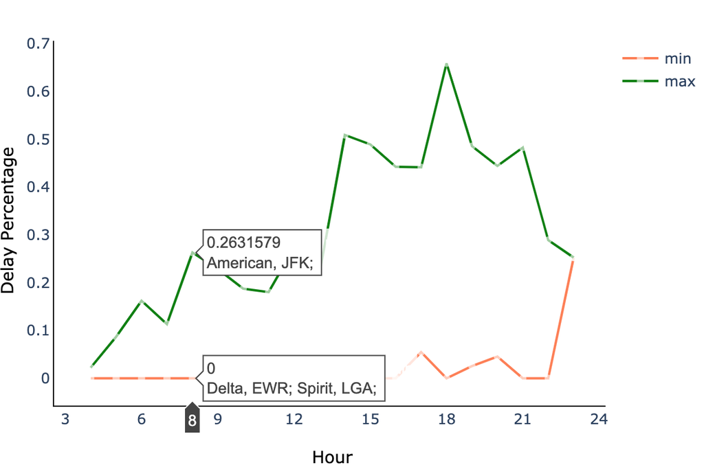

```python
print("8 am")
Image("figures/time_delay_1.png")
```

```
8 pm
```

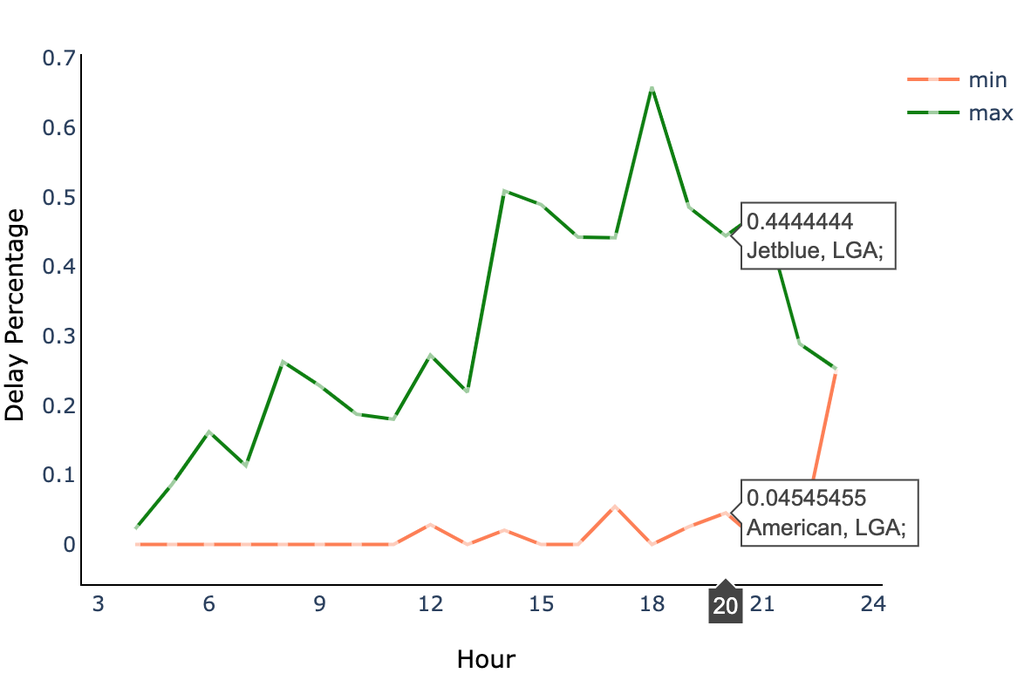

```python
print("8 pm")
Image("figures/time_delay_0.png")
```

At different time (exp. 8am and 8pm), the best performance has been achieved by different airlines, also, same airline, like American, at different airport, different time, its performance can change a lot.

#### delay percentage for each delay type for each airline

```python
fig, ax = plt.subplots(figsize=[12,12])
problems = ["airline_delay", "weather_delay", "air_system_delay", "security_delay", "aircraft_delay"]
for idx, i in enumerate(NewYork_EWR_flights_delay.groupby("airline_name")):
    plt.subplot(4,3,idx+1)
    plt.title(i[0])
    sns.barplot(x=problems, y=[i[1][i[1][p]!= 0.0].shape[0]/NewYork_EWR_flights[NewYork_EWR_flights["airline_name"] == i[0]].shape[0] for p in problems])
    print([i[1][i[1][p]!= 0.0].shape[0]/NewYork_EWR_flights[NewYork_EWR_flights["airline_name"] == i[0]].shape[0] for p in problems])
    plt.xticks(rotation= 45)
plt.tight_layout();
```

[output not shown]

```
[0.05128205128205128, 0.02564102564102564, 0.15384615384615385, 0.010256410256410256, 0.11282051282051282]
[0.11398963730569948, 0.034974093264248704, 0.13082901554404144, 0.025906735751295335, 0.11528497409326424]
[0.13211009174311927, 0.025688073394495414, 0.09357798165137615, 0.007339449541284404, 0.15045871559633028]
[0.17430441898527005, 0.06423895253682488, 0.20540098199672668, 0.060147299509001634, 0.1988543371522095]
[0.31413612565445026, 0.04607329842931937, 0.2198952879581152, 0.04397905759162304, 0.2942408376963351]
[0.05217391304347826, 0.034782608695652174, 0.19130434782608696, 0.02608695652173913, 0.23478260869565218]
[0.18351477449455678, 0.029548989113530325, 0.15241057542768274, 0.01866251944012442, 0.2208398133748056]
[0.10064935064935066, 0.05844155844155844, 0.275974025974026, 0.05844155844155844, 0.06818181818181818]
[0.14220767412256774, 0.027641389343517002, 0.1425713766139298, 0.015457355882887798, 0.13893435170030916]
[0.08502024291497975, 0.048582995951417005, 0.1902834008097166, 0.008097165991902834, 0.10526315789473684]
```

### Airline vs Delay Time

```python
airline_EWR_df["average_delay"] = airline_EWR_df["total_delay_time"]/ airline_EWR_df["only_delay"]
airline_JFK_df["average_delay"] = airline_JFK_df["total_delay_time"]/ airline_JFK_df["only_delay"]
airline_LGA_df["average_delay"] = airline_LGA_df["total_delay_time"]/ airline_LGA_df["only_delay"]
```

```python
NewYork_EWR_flights_delay["total_delay_time"].describe()
```

```
count    2891.000000
mean       69.178139
std        68.502689
min        15.000000
25%        26.000000
50%        47.000000
75%        88.000000
max       867.000000
Name: total_delay_time, dtype: float64
```

```python
NewYork_JFK_flights_delay["total_delay_time"].describe()
```

```
count    2215.000000
mean       71.199549
std        73.040169
min        15.000000
25%        26.000000
50%        46.000000
75%        90.000000
max       898.000000
Name: total_delay_time, dtype: float64
```

```python
NewYork_LGA_flights_delay["total_delay_time"].describe()
```

```
count    1958.000000
mean       75.845250
std        93.857643
min        15.000000
25%        26.000000
50%        45.500000
75%        91.000000
max      1165.000000
Name: total_delay_time, dtype: float64
```

#### Total delay time for different airports

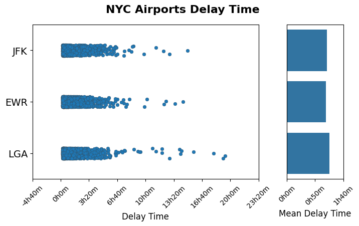

```python
# Create figure and axes
fig, (ax1, ax2) = plt.subplots(
    1, 2,
    figsize=(8, 4),
    gridspec_kw={'width_ratios': [4, 1]}
)
fig.suptitle("NYC Airports Delay Time", size=16, weight="bold")

# --- Left plot: Strip plot ---
sns.stripplot(
    x="total_delay_time",
    y="origin_airport",
    data=NewYork_flights_delay,
    jitter=True,
    linewidth=0.2,
    ax=ax1
)
ax1.set_xticks(ax1.get_xticks())
ax1.set_xticklabels(
    [f"{int(h)}h{int(m)}m" for h, m in (divmod(x, 60) for x in ax1.get_xticks())],
    rotation=45,
    size=10
)
ax1.tick_params(axis="y", labelsize=14)
ax1.set_ylabel(None)
ax1.set_xlabel("Delay Time", size=12)

# --- Right plot: Mean delay time per airport ---
mean_delays = [
    NewYork_flights_delay[NewYork_flights_delay["origin_airport"] == a]["total_delay_time"].mean()
    for a in ["JFK", "EWR", "LGA"]
]
sns.barplot(
    x=mean_delays,
    y=["JFK", "EWR", "LGA"],
    orient="h",
    ax=ax2
)
ax2.set_xticks(ax2.get_xticks())
ax2.set_xticklabels(
    [f"{int(h)}h{int(m)}m" for h, m in (divmod(x, 60) for x in ax2.get_xticks())],
    rotation=45,
    size=10
)
ax2.set_yticks([])  # hide y-axis labels
ax2.set_xlabel("Mean Delay Time", size=12)

#plt.tight_layout(pad=1)
plt.show()
```

If we compare the delay time of three airports, EWR has the lowest average delay time for delay flights, but LGA has some outliers with very large delay time.

#### Delay time for different airline (use EWR as an example)

```python
%%capture
# Create figure and axes
fig, (ax1, ax2) = plt.subplots(
    1, 2,
    figsize=(8, 8),
    gridspec_kw={'width_ratios': [3, 1]}
)

# --- Left plot: Strip plot ---
sns.stripplot(
    x="total_delay_time",
    y="airline_name",
    data=NewYork_EWR_flights_delay,
    jitter=True,
    linewidth=0.2,
    ax=ax1
)
ax1.set_xticks(ax1.get_xticks())
ax1.set_xticklabels(
    [f"{int(h)}h{int(m)}m" for h, m in (divmod(x, 60) for x in ax1.get_xticks())],
    rotation=45,
    size=10
)
ax1.tick_params(axis="y", labelsize=14)
ax1.set_ylabel(None)
ax1.set_xlabel("Delay Time", size=12)

# --- Right plot: Mean delay time per airline ---
airlines = ["American", "Jetblue", "Delta", "ExpressJet", "Spirit",
            "SkyWest", "United", "Southwest", "Alaska", "Virgin"]

mean_delays = [
    airline_EWR_df[airline_EWR_df["index"] == a]["average_delay"].values[0]
    for a in airlines
]

sns.barplot(
    x=mean_delays,
    y=airlines,
    orient="h",
    ax=ax2
)
ax2.set_xticks(ax2.get_xticks())
ax2.set_xticklabels(
    [f"{int(h)}h{int(m)}m" for h, m in (divmod(x, 60) for x in ax2.get_xticks())],
    rotation=45,
    size=10
)
ax2.set_yticks([])  # remove y-axis labels
ax2.set_xlabel("Mean Delay Time", size=12)

plt.tight_layout(pad=3)
plt.savefig("figures/delay_time_EWR.pdf", dpi=300)
plt.show()
```

[output not shown]

[output not shown]

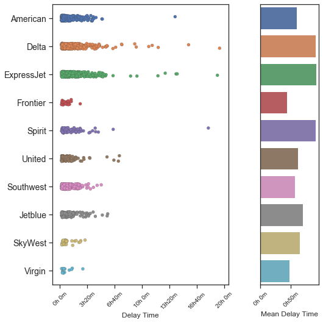

```python
#font = { 'weight' : 'bold', 'size'   : 12}
#matplotlib.rc('font', **font)
#matplotlib.style.use('default')
fig, (ax1, ax2) = plt.subplots(1,2, figsize=[8,8], gridspec_kw={'width_ratios': [3, 1]})
#fig.suptitle("EWR", size=16, weight="bold")
plt.subplot(ax1)
ax = sns.stripplot(x="total_delay_time", y="airline_name", data=NewYork_LGA_flights_delay, jitter=True, linewidth=0.2)
plt.xticks(rotation="45", size=10)
ax.set_xticklabels(['{:2.0f}h{:2.0f}m'.format(*[int(y) for y in divmod(x,60)]) for x in ax.get_xticks()])
plt.yticks(size=14)
#plt.ylim(ymin=0)
#ax.annotate("std=80m")
plt.ylabel(None)
plt.xlabel("Delay Time", size=12);
plt.subplot(ax2)
#plt.figure(figsize=[4,6])
airlines = ["American", "Delta", "ExpressJet", "Frontier", "Spirit",  "United", "Southwest", "Jetblue", "SkyWest", "Virgin"]
ax2=sns.barplot([airline_LGA_df[airline_LGA_df["index"] == a]["average_delay"].values[0] for a in airlines],
            airlines, orient="h")
ax2.set_xticklabels(['{:2.0f}h{:2.0f}m'.format(*[int(y) for y in divmod(x,60)]) for x in ax2.get_xticks()])
plt.yticks([],[])
plt.xticks(rotation="45", size=10)
plt.xlabel("Mean Delay Time", size=12)
plt.tight_layout(pad=3);
plt.savefig("figures/delay_time_LGA.pdf", dpi=300);
```

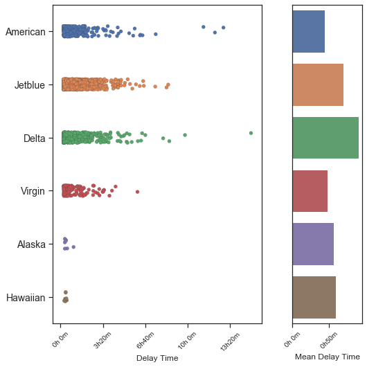

```python
fig, (ax1, ax2) = plt.subplots(1,2, figsize=[8,8], gridspec_kw={'width_ratios': [3, 1]})
plt.subplot(ax1)
ax = sns.stripplot(x="total_delay_time", y="airline_name", data=NewYork_JFK_flights_delay, jitter=True, linewidth=0.2)
plt.xticks(rotation="45", size=10)
ax.set_xticklabels(['{:2.0f}h{:2.0f}m'.format(*[int(y) for y in divmod(x,60)]) for x in ax.get_xticks()])
plt.yticks(size=14)
#plt.ylim(ymin=0)
#ax.annotate("std=80m")
plt.ylabel(None)
plt.xlabel("Delay Time", size=12);
plt.subplot(ax2)
#plt.figure(figsize=[4,6])
airlines = ["American", "Jetblue", "Delta",  "Virgin", "Alaska", "Hawaiian"]
ax2=sns.barplot([airline_LGA_df[airline_JFK_df["index"] == a]["average_delay"].values[0] for a in airlines],
            airlines, orient="h")
ax2.set_xticklabels(['{:2.0f}h{:2.0f}m'.format(*[int(y) for y in divmod(x,60)]) for x in ax2.get_xticks()])
plt.yticks([],[])
plt.xticks(rotation="45", size=10)
plt.xlabel("Mean Delay Time", size=12)
plt.tight_layout(pad=3);
plt.savefig("figures/delay_time_JFK.pdf", dpi=300);
```

There are some large outliers(larger than 10h), which should be noted and conduct further analysis.

#### Classify airline delay into different type based on delay time

since the average delay time of EWR is 69 and std 25% is 26 and 75% is 88, we just used these three value to classify delay time into small delay, medium delay and large delay.

```python
NewYork_EWR_flights_onlydelay = NewYork_EWR_flights_delay[NewYork_EWR_flights_delay["airline_delay"].notnull()]
```

```python
NewYork_EWR_flights_onlydelay["class"] = np.where(NewYork_EWR_flights_onlydelay["total_delay_time"] >88, "high",
                                  np.where(NewYork_EWR_flights_onlydelay["total_delay_time"] >26, "medium", "small"))
```

```python
NewYork_EWR_flights_onlydelay.groupby("airline_name")
```

```
<pandas.core.groupby.generic.DataFrameGroupBy object at 0x00000226EE593D10>
```

```python
class_EWR_df = NewYork_EWR_flights_onlydelay.groupby(["airline_name","class"]).agg({ "total_delay_time": len})
```

```python
class_EWR_df.reset_index(inplace=True)
class_EWR_df.rename(columns={"total_delay_time": "only_delay"}, inplace=True)
class_EWR_df.head()
```

|  | airline_name | class | only_delay |
| --- | --- | --- | --- |
| 0 | Alaska | high | 9 |
| 1 | Alaska | medium | 17 |
| 2 | Alaska | small | 13 |
| 3 | American | high | 24 |
| 4 | American | medium | 63 |

```python
class_EWR_df = pd.merge(class_EWR_df, airline_EWR_df[["index", "total_flights"]], left_on="airline_name", right_on="index")
```

```python
class_EWR_df["delay_percentage"] = class_EWR_df["only_delay"]/class_EWR_df["total_flights"]
```

```python
plt.figure(figsize=[8,6])
sns.catplot(y="airline_name", x="delay_percentage", hue="class", data=class_EWR_df, kind="bar", palette="muted");
```

[output not shown]